# Assignment 1

Density Estimation and Clustering

Alexander, Ulrik, Hannes

23/feb./2022

# Load Boston Housing Data

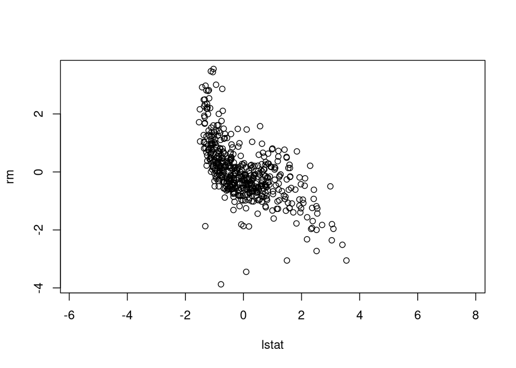

```r
data("Boston", package = "MASS")
X <- scale(Boston[,c(13,6)])
plot(X,as=1)
```

# Questions

## 1. Estimate Joint Bivariate Density

We want to estimate the joint bivariate density using a kernel estimator with the same bandwidth in both dimensions: $h = (a, a)$. The maximum log-likelihood cross-validation method will be used to choose the value of $a$. Then, the density will be estimated using this value of $a$. Some level curves of this estimated density are plotted below.

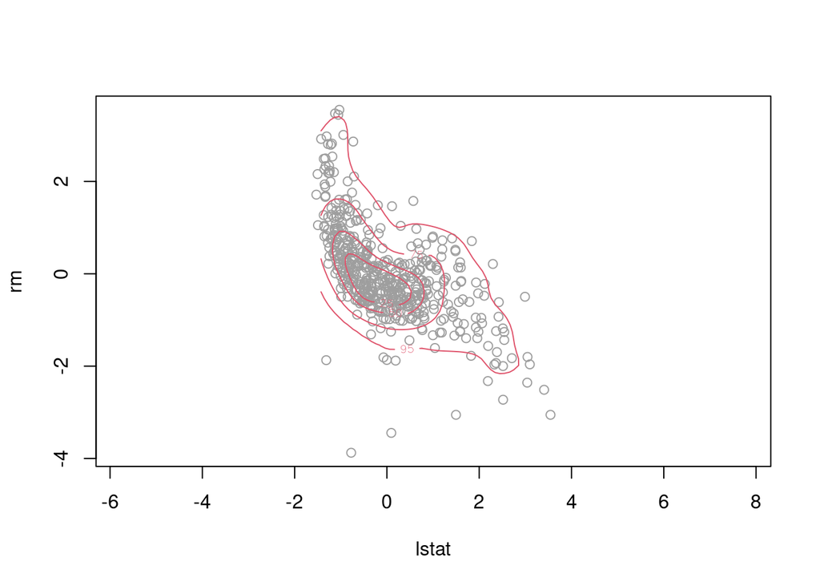

```r
optimal.bandwidth <- function(x, grid){
   # Number of data points
   n <- dim(x)[1]

   # Create storage for the sample log-likelihoods
   f.hat.cv <- matrix(0, nrow = length(grid))

   # Iterate through a values
   for (i in 1:length(grid)) {
     # Iterate over all data points
     for (j in 1:n) {
       # Remove data point j from the data
       point.j <- matrix(x[j,], ncol = 2)
       X.j <- x[-j,]
       # Calculate the likelihood of x.j (with x.j left out)
       f.hat.j <- sm.density(X.j, h = grid[i]*c(1,1), display="none",
                             eval.grid = F, eval.points = point.j)$estimate
       # Add the logarithm of the estimate to the total log-likelihood
       f.hat.cv[i] <- f.hat.cv[i] + log(f.hat.j)
     }
   }

   # Maximum likelihood cross-validation value of a
   return(grid[which.max(f.hat.cv)])
}

# Valid choice of a
a.domain <- seq(0.1, 1, by = 0.1)

a.ml <- optimal.bandwidth(X, a.domain)

# Plotting the density estimation with our chosen a value
plot(X, as = 1, col = 8)
sm.density(X, h = a.ml*c(1,1), display = "slice",
           props = c(25,50,75,95), col = 2, add = T)
```

The optimal value on the discrete grid of $a$’s

```r
a.domain
```

```
#>  [1] 0.1 0.2 0.3 0.4 0.5 0.6 0.7 0.8 0.9 1.0
```

is 0.3.

## 2. Hierarchical Clustering

Hierarchical clustering using the **ward.D** method. The dendrogram is shown below.

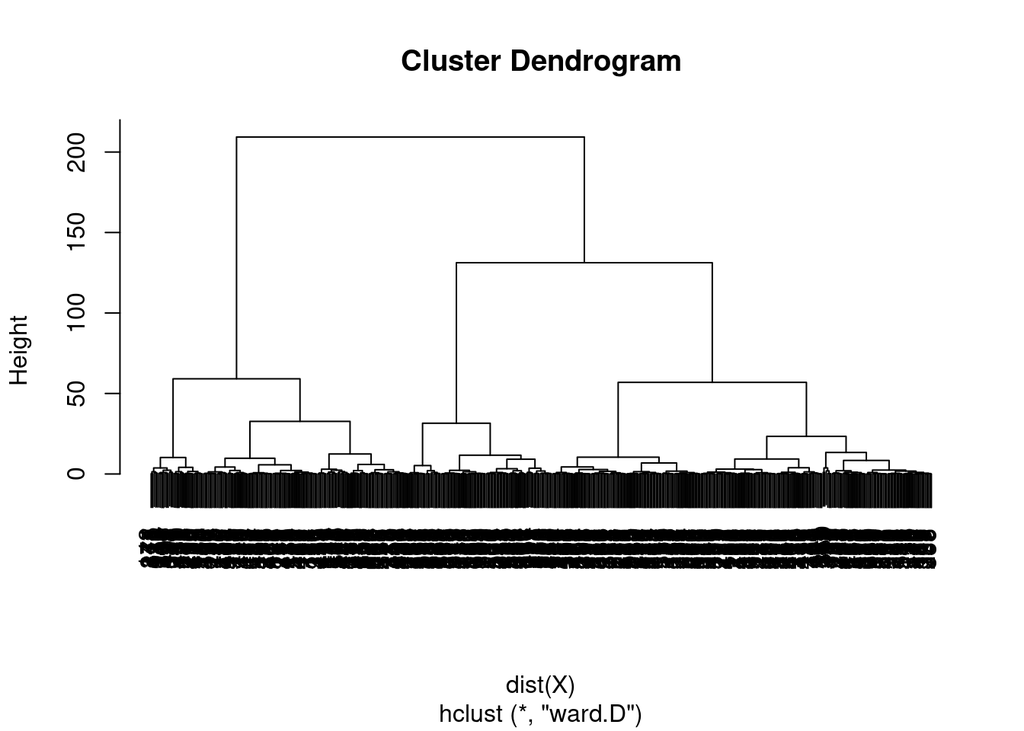

```r
hcl1 <- hclust(dist(X), method="ward.D") # Euclidean distance, ward.D method.
plot(hcl1)
```

The dendrogram is cut into $k = 3$ clusters. The scatterplot below shows how the points are distributed in the three clusters.

```r
clusts <- cutree(hcl1, 3)
table(clusts)
```

```
#> clusts
#>   1   2   3
#> 246  93 167
```

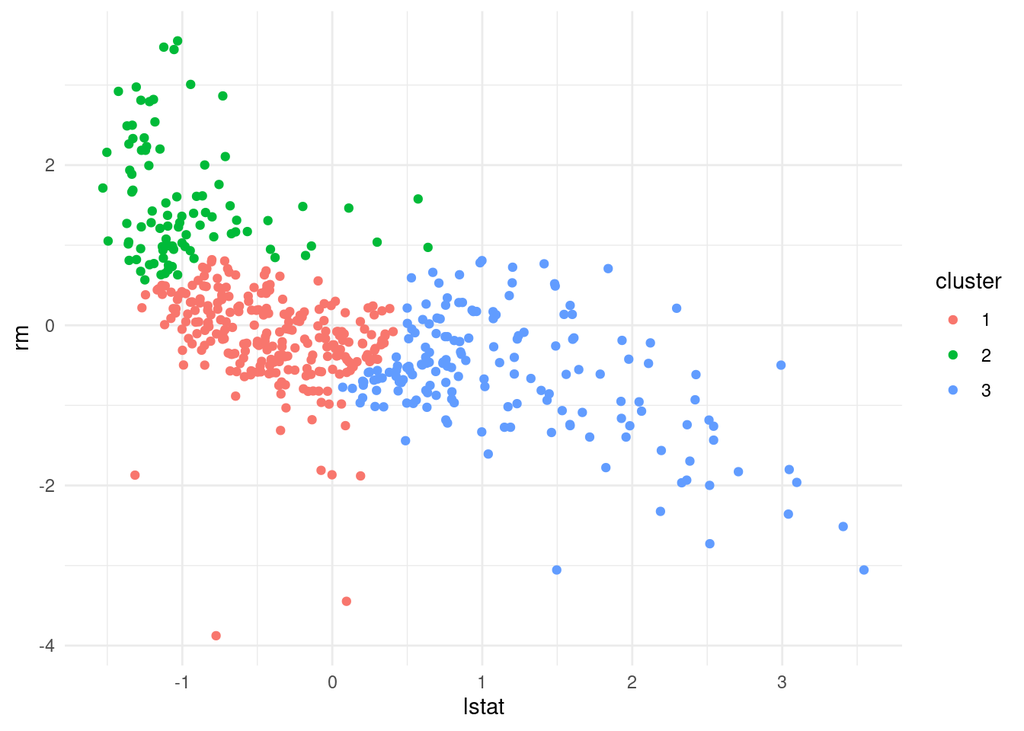

```r
df <- data.frame(lstat = X[,1], rm = X[,2], cluster = factor(clusts))
ggplot(df, aes(x = lstat, y = rm)) +
   geom_point(aes(colour = cluster)) +
   theme_minimal()
```

## 3. For each of the Clusters, do …

- Estimate the joint bivariate density conditional to the cluster.
- Represent the estimated bivariate density with the 75% level curve.

### Cluster 1

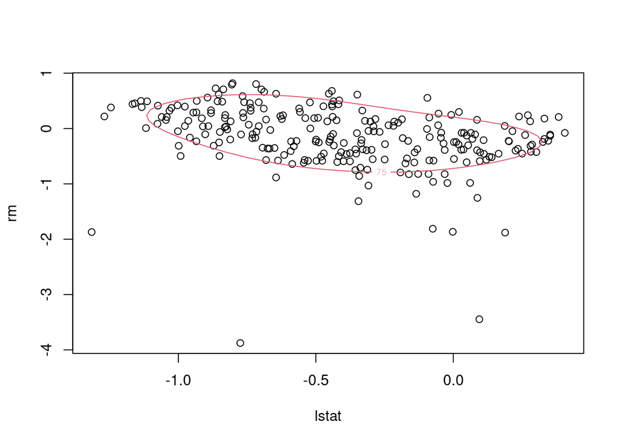

```r
# Data from cluster 1.
clust1.data <- df %>% dplyr::filter(cluster == "1")

# Non-parametric estimation of the joint density.
plot(clust1.data[, c(1,2)])
sm.density(clust1.data[, c(1,2)], h = a.ml*c(1,1), display="slice",props=c(75),col=2,add=TRUE)
```

### Cluster 2

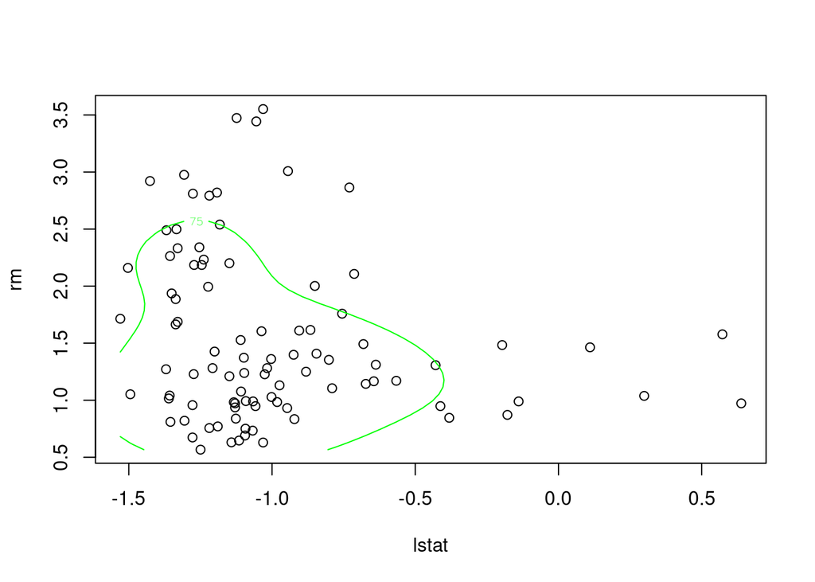

```r
# Data from cluster 1.
clust2.data <- df %>% dplyr::filter(cluster == "2")

# Non-parametric estimation of the joint density.
plot(clust2.data[, c(1,2)])
sm.density(clust2.data[, c(1,2)], h = a.ml*c(1,1), display="slice",props=c(75),col="green",add=TRUE)
```

### Cluster 3

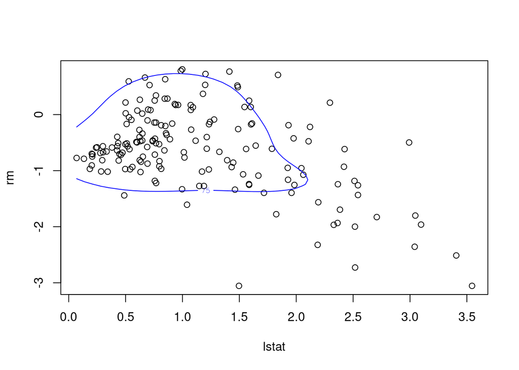

```r
# Data from cluster 1.
clust3.data <- df %>% dplyr::filter(cluster == "3")

# Non-parametric estimation of the joint density.
plot(clust3.data[, c(1,2)])
sm.density(clust3.data[, c(1,2)], h = a.ml*c(1,1), display="slice",props=c(75),col="blue",add=TRUE)
```

### Combined Plot

The 75% level curves of all three estimated densities are plotted below.

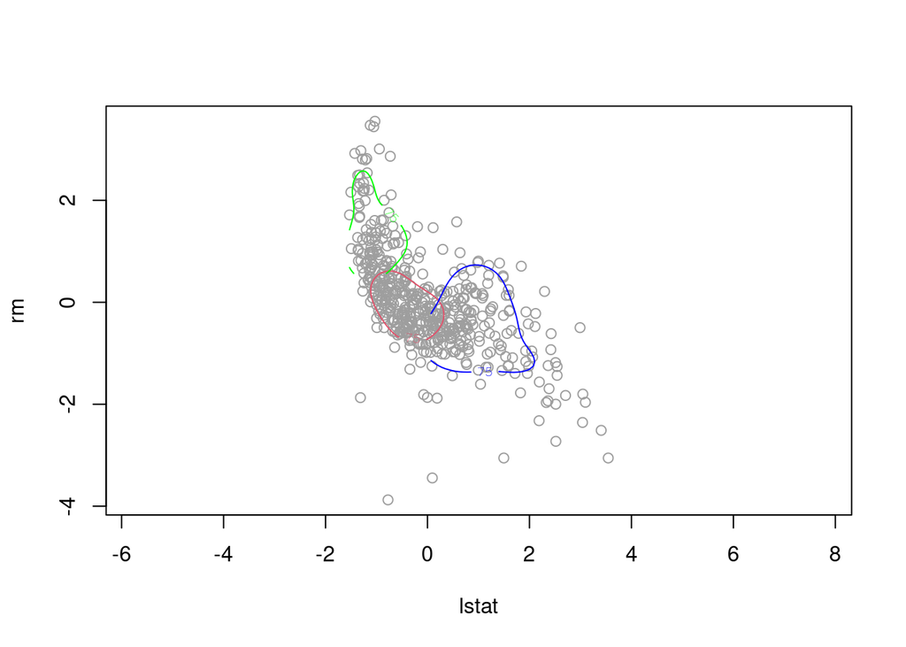

```r
#plot(df[, c(1,2)], as=1, col = df[, 3])
plot(X, as = 1, col = 8)
sm.density(clust1.data[, c(1,2)], h = a.ml*c(1,1), display="slice",props=c(75),col=2,add=TRUE)
sm.density(clust2.data[, c(1,2)], h = a.ml*c(1,1), display="slice",props=c(75),col="green", add=TRUE)
sm.density(clust3.data[, c(1,2)], h = a.ml*c(1,1), display="slice",props=c(75),col="blue", add=TRUE)
```

## 4. Repeat 2 and 3, with Automatically Selected Optimal Number of Clusters

### Gap Statistic

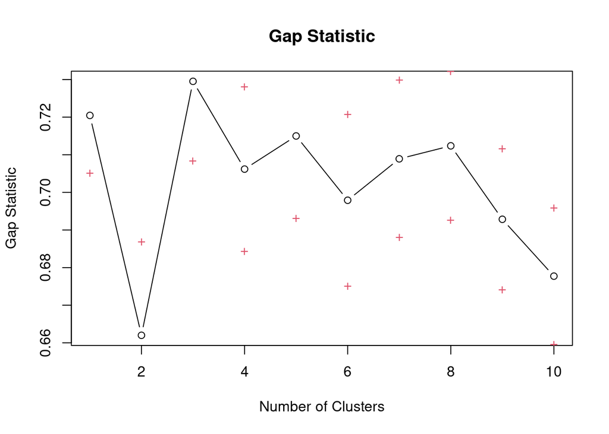

```r
# Create a function doing hclust and cutree.
hclusCut <- function(x, k, d.meth = "euclidean", ...){
   list(cluster = cutree(hclust(dist(x, method=d.meth), ...), k=k))
}

K.max <- 10
Gap <- clusGap(X, FUNcluster=hclusCut, K.max=K.max, B = 500, method="ward.D")
plot(1:K.max,Gap$Tab[,"gap"],type="b", xlab = "Number of Clusters", ylab = "Gap Statistic", main = "Gap Statistic")
points(1:K.max,Gap$Tab[,"gap"]+ Gap$Tab[,"SE.sim"],pch="+", col=2)
points(1:K.max,Gap$Tab[,"gap"]- Gap$Tab[,"SE.sim"],pch="+",col=2)
```

Using the gap statistic as a model choice criterion we choose the first $k$ such that the gap statistic is larger or equal to the next $(k+1)$ statistic subtracted its standard deviation. The gap statistic suggests using $k = 1$ (or $k = 3$) cluster(s).

### Calinski and Harabasz index (CH-index)

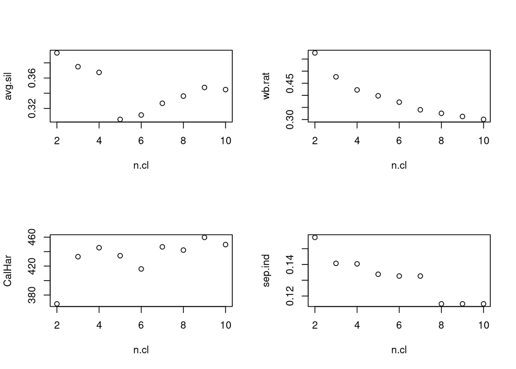

```r
n.cl <- 2:10
l.n.cl<-length(n.cl)

avg.sil <- rep(NA, l.n.cl)
w <- rep(NA, l.n.cl)
wb.rat <- rep(NA, l.n.cl)
sep.ind <- rep(NA, l.n.cl)
CalHar <- rep(NA, l.n.cl)

for (i in (1:l.n.cl)){
  k<-n.cl[i]
  d <- dist(X)
  hcl.Eucl <- hclust(d, method="ward.D")
  cut.hcl.Eucl <- cutree(hcl.Eucl,k)
  cl.stats <- cluster.stats(d,cut.hcl.Eucl)
  avg.sil[i]   <- cl.stats$avg.silwidth
  w[i]    <- cl.stats$average.within
  wb.rat[i]    <- cl.stats$wb.ratio
  sep.ind[i]   <- cl.stats$sindex
  CalHar[i]   <- cl.stats$ch
}
op<-par(mfrow=c(2,2))
plot(n.cl,avg.sil)
plot(n.cl,wb.rat)
#plot(n.cl,w)
plot(n.cl,CalHar)
plot(n.cl,sep.ind)
```

The lower left plot shows the CH-index, which has the values

```r
rbind("Clusters" = n.cl, "CH" = CalHar)
```

```
#>              [,1]     [,2]    [,3]     [,4]     [,5]     [,6]     [,7]     [,8]
#> Clusters   2.0000   3.0000   4.000   5.0000   6.0000   7.0000   8.0000   9.0000
#> CH       367.8201 432.9759 445.374 434.3341 416.0564 446.5451 442.0742 459.6494
#>             [,9]
#> Clusters  10.000
#> CH       449.704
```

It suggests using $k = 9$ clusters, since this is the maximum among the values of the index. This does however seem like a lot of clusters in this case. Thus, based on the values above, one could perhaps also choose $k = 4$ or $k = 7$, since the CH-index for these values are almost as large as for $k = 9$. We also keep in mind that a simpler model is easier to interpret (as well as the principle of parsimony) and thus preferred when other model choice criteria are similar

Based on the two methods used, we will choose $k = 4$ clusters as the optimal amount. Note that the gap statistic at $k = 4$ is larger than the gap statistic at $k = 5$ subtracted its standard deviation. Thus, we argue that $k = 4$ is a fair choice based on the gap statistic as well, despite the fact that it is not the smallest $k$ such that the model choice criterion holds.

### Hierarchical Clustering; Cutting Dendrogram at $k = 4$

The dendrogram is cut into $k = 4$ clusters. The scatterplot below shows how the points are distributed in the four clusters.

```r
cluster.number <- 4
clusts2 <- cutree(hcl1, cluster.number)
table(clusts2)
```

```
#> clusts2
#>   1   2   3   4
#> 246  93 133  34
```

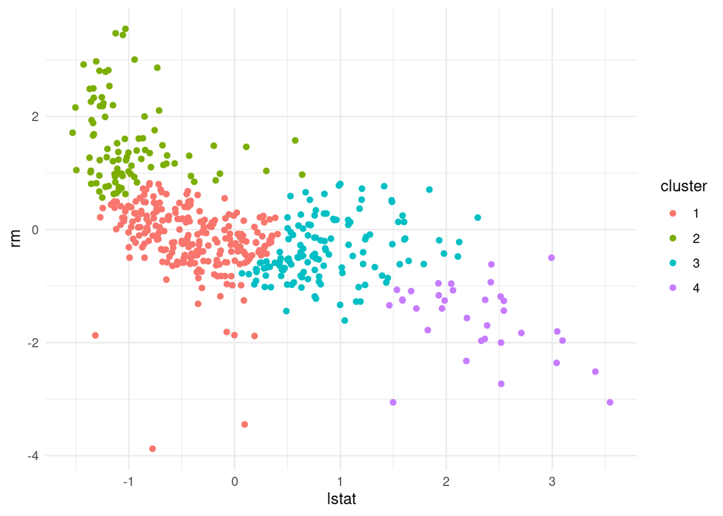

```r
df2 <- data.frame(lstat = X[,1], rm = X[,2], cluster = factor(clusts2))
ggplot(df2, aes(x = lstat, y = rm)) +
   geom_point(aes(colour = cluster)) +
   theme_minimal()
```

### Select Optimal Bandwidth and Estimate Densities in Each Cluster

The 75% level curves of all four estimated densities are plotted below.

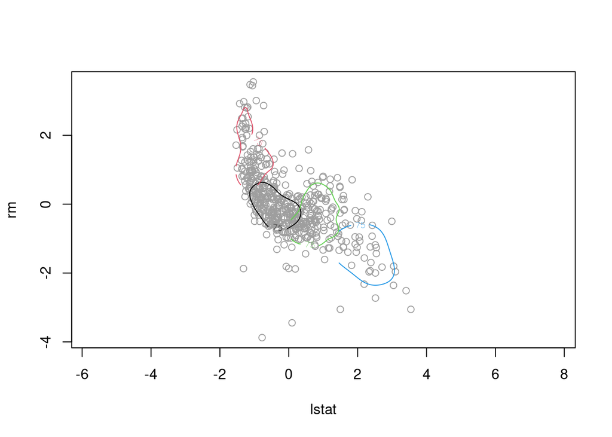

```r
a.mls <- rep(NA, cluster.number)
plot(X, as = 1, col = 8)

for (i in 1:cluster.number){
   clust.data2 <- df2 %>% dplyr::filter(cluster == i)
   a.mli <- optimal.bandwidth(data.matrix(clust.data2 %>% select(c("lstat", "rm"))), a.domain)
   a.mls[i] <- a.mli
   # The lines below are just to avoid the gray color of the points.
   colo <- i
   if (colo == 8){
      colo <- 'mediumorchid2'
   }
   sm.density(clust.data2[, c(1,2)], h = a.mli*c(1,1), display="slice",props=c(75),col=colo,add=TRUE)
}
```

Note that the optimal bandwidth is selected separately for each cluster in order to improve the final density estimations. The optimal bandwidth in each cluster (based on the same grid of a-values from point 1) is

```r
rbind("Clusters" = 1:cluster.number, "Opt. Bandwidth" = a.mls)
```

```
#>                [,1] [,2] [,3] [,4]
#> Clusters        1.0  2.0  3.0  4.0
#> Opt. Bandwidth  0.2  0.2  0.2  0.4
```